# Lecture #15

산점도 작성

Junho Ahn

2022-09-08

## 산점도

### 산점도와 plot함수

**산점도(scatterplot)**

- $(x_1, y_1),(x_2, y_2), \dots ,(x_n, y_n)$의 짝으로 얻어진 자료의 $(x_i, y_i)$에 대해 좌표평면에 x축 값이 $x_i$, y축 값이 $y_i$인 곳에 점으로 표시하는 그림
- $n$개의 짝이 있으면 산점도엔 $n$개이 점이 표시되며 이 점들에 의해 두 변수 x와 y사이의 관계를 직관적으로 확인 가능

### 산점도 및 함수 그리기

(자료를 사용한 산점도 그리기 및 함수 그리기)  
1. BMI 자료를 사용하여 키와 몸무게의 산점도  
2. 함수 $y=f(x)=x^2$을 $-10 \leq x \leq 10$에서 그려보자.

```r
BMI <- read.csv("./Lecture01_BMI.csv")
```

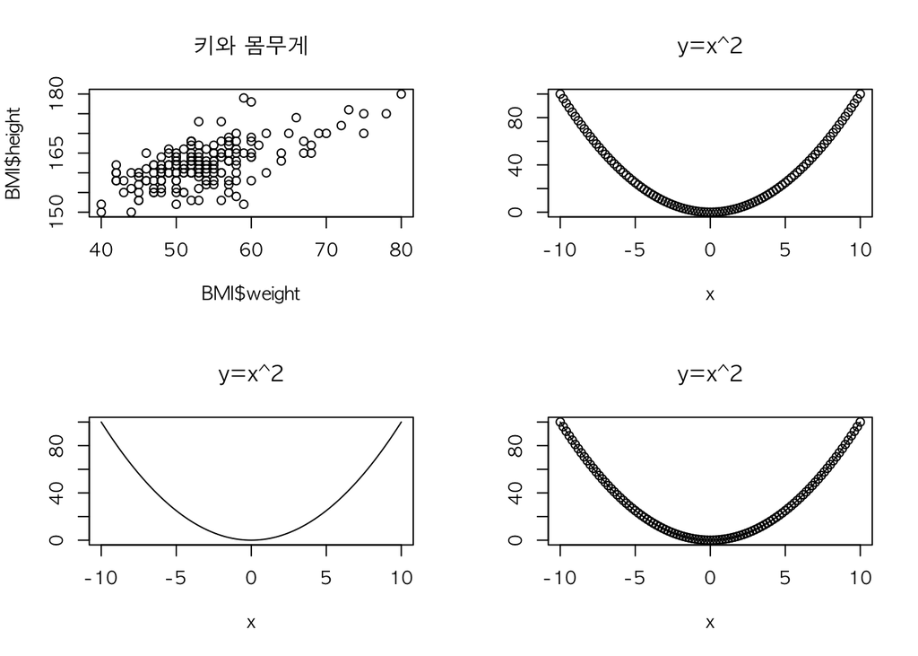

```r
par(mfrow=c(2,2), family = "AppleGothic")
plot(BMI$weight, BMI$height, main = "키와 몸무게")
plot(x <- seq(-10, 10, by = 0.2), y <- x^2, xlab = "x", ylab = "", main = "y=x^2")
plot(x <- seq(-10, 10, by = 0.2), y <- x^2, xlab = "x", ylab = "", main = "y=x^2", type = "l")
plot(x <- seq(-10, 10, by = 0.2), y <- x^2, xlab = "x", ylab = "", main = "y=x^2", type = "o")
```

## 행렬산점도

### 행렬산점도 그리기

(자료) 키, 몸무게 자료에 BMI에서 키, 몸무게, 출생연도에 대한 모든 가능한 산점도를 그려보자.

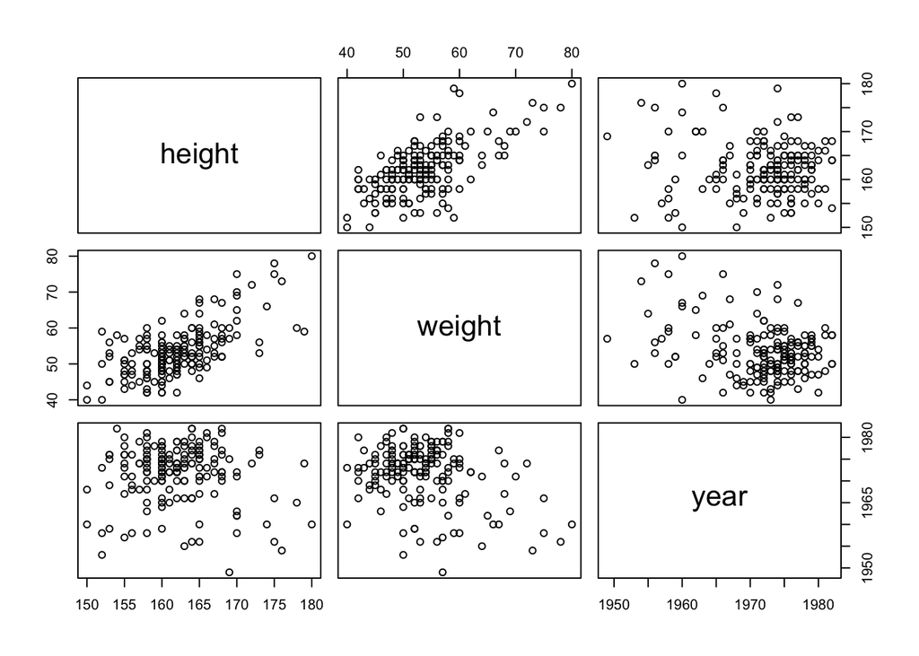

```r
pairs(~height+weight+year, data = BMI)
```

- 모든 옵션이 기본값으로 설정된 결과
- 변수 이름이 순서대로 height, weight, year로 나타나며 변수 이름은 왼쪽 위부터 오른쪽 아래로 내려감

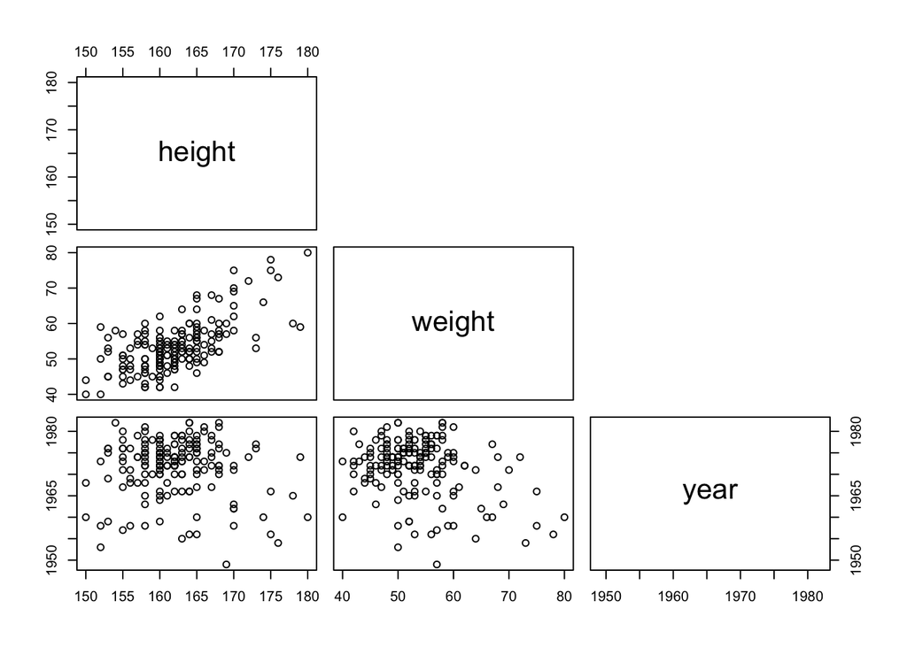

```r
pairs(~height+weight+year, data=BMI, upper.panel=NULL)
```

- upper.panel = NULL 옵션에 의해 대각선 위의 그림은 없음

```r
pairs.test <- function() {
  pairs(~height+weight+year, data=BMI, subset = gender == "F",
        labels = c("height(cm)", "weight(kg)", "year"), row1attop = FALSE)
} #end function
```

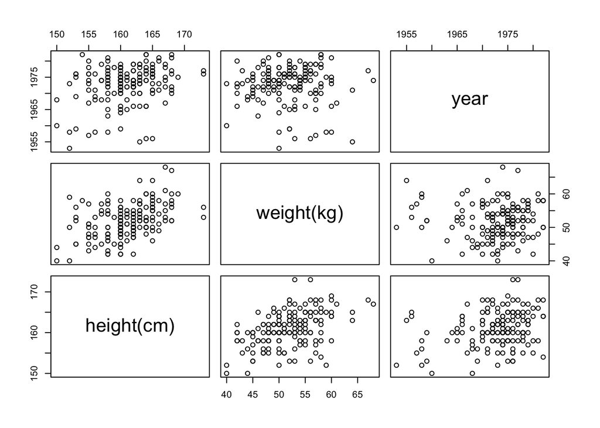

```r
pairs.test()
```

- 자료는 subset 속성의 설정에 의해 성별이 여자(F)인 경우만 산점도를 얻었음
- 반대각선에 있는 이름은 labels에서 설정한 이름들임
- row1attop = FALSE 옵션에 의해 대각선의 방향도 바뀜

(대각선에 함수를 사용하여 결과 인쇄) 앞의 결과를 보면 대각선엔 문자열이 들어가지만 함수의 결과(출력)를 대각선에 이력하는 다음의 방법을 생각해보자. (diag.panel에 사용자 작성함수 지정)

```r
my.panel.text <- function(x, ...) {
  mx <- as.character(round(mean(x),1))
  mystr <- paste("평균 \n", mx, sep="")
  h <- hist(x, plot = FALSE)
  xloc <- mean(h$breaks)
  yloc <- xloc
  text(xloc, yloc, mystr, cex=2, col=2)
}
```

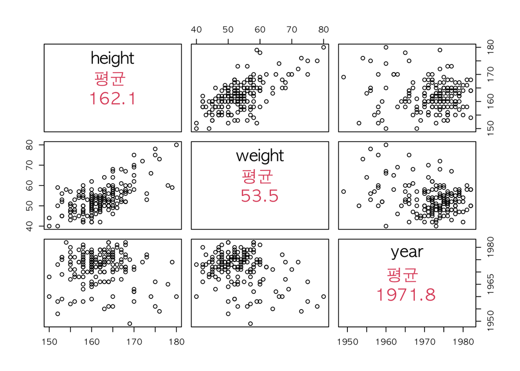

```r
par(family = "AppleGothic")
pairs(~height+weight+year, data=BMI, diag.panel=my.panel.text)
```

**함수설명**

- `my.panel.text()`함수는 매개변수 x를 받아서
- x의 평균을 소수점 1자리까지만 문자열로 변환하고
- “평균”이라는 문자열을 추가하여 mystr이라 함
- hist함수를 호출하되, 그림은 그리지 않고 출력만 받아 h라 하고
- 히스토그램의 각 기둥의 x 좌표들의 평균을 xloc, yloc라 함
- 좌표(xloc, yloc)에 문자열을 그림
- `pairs()`함수에서 diag.panel에 `my.panel.text()`함수를 설정하여
- 이 함수의 결과인 평균을 빨간색으로 대각선에 출력함

## 두 개이상의 산점도 겹치기

### matplot함수

__matplot()__는 주어진 하나의 x벡터값에 대해서 두 개 이상의 y벡터에 대한 산점도를 그리는 함수

### 중복한 산점도 또는 함수 그리기

(두 함수를 겹쳐 그리기)  
* $x$가 $-\pi$부터 $\pi$사이의 100개의 값일 때 $sin(x)$와 $cos(x)$를 한 그림에 겹쳐 그린 보기임  
* $y$는 $x$의 100개의 값을 $sin(x)$와 $cos(x)$의 값을 각각 첫번째 및 두번째 열로 갖는 행렬

```r
matplot.test <- function(){
  par(mfrow=c(1,2), family = "AppleGothic")
  x <- seq(-pi, pi, length = 100) # -pi ~ pi 사이의 100개 값을 벡터로
  y <- cbind(sin(x), cos(x)) # x에서 sin 및 cos 함수의 값 계산
  matplot(x, y, type = "l", main = "기본설정") # x에서 sin과 cos 함수 그리기
  matplot(y, type = "p", pch = 16, main = "한 값만 입력") # y만 입력된 경우 x는 (1,100)
} # end function
```

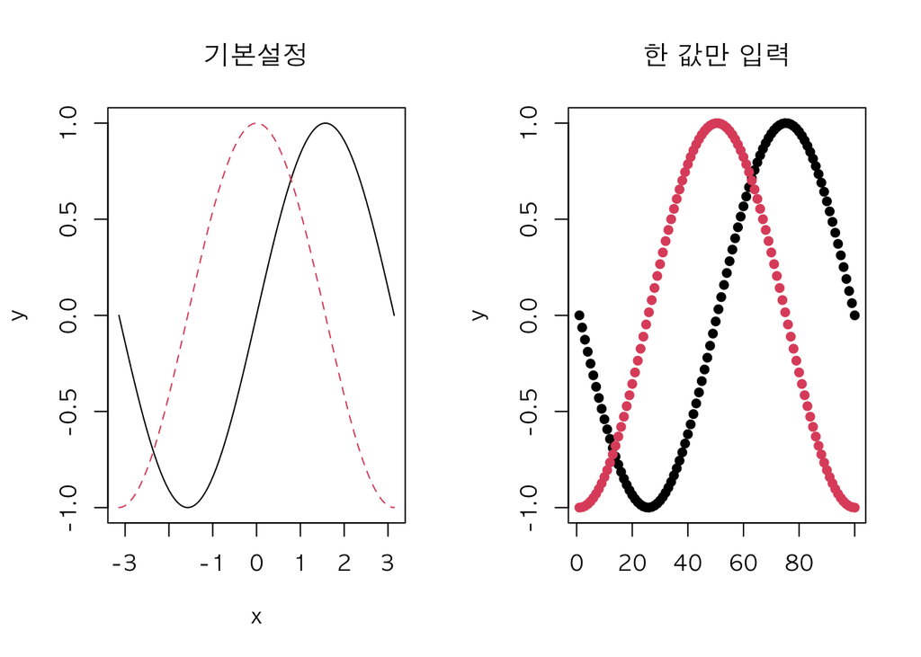

```r
matplot.test()
```

- 한 값만 입력할 경우 $x$의 입력을 생략하였으므로 $x$가 1부터 100사이인 것으로 간주함

```r
df <- readxl::read_xlsx("./grdp.xlsx", skip = 1)
head(df)
```

| ...1 | 2006 | 2007 | 2008 | 2009 | 2010 | 2011 | 2012 | 2013 | 2014 |
| --- | --- | --- | --- | --- | --- | --- | --- | --- | --- |
| 전국 | 966660 | 1043255 | 1105722 | 1151367 | 1265146 | 1330888 | 1377041 | 1430255 | 1484542 |
| 서울 | 231224 | 249485 | 263000 | 273199 | 289719 | 303813 | 313479 | 318607 | 327602 |
| 부산 | 52358 | 56193 | 60467 | 60695 | 63737 | 66648 | 67999 | 70338 | 73744 |
| 대구 | 32276 | 34388 | 35465 | 36017 | 38580 | 41448 | 43021 | 44754 | 46592 |
| 인천 | 47055 | 51638 | 51274 | 53796 | 60708 | 61854 | 62208 | 64654 | 68374 |
| 광주 | 20614 | 22310 | 22940 | 23834 | 26401 | 27789 | 28914 | 29763 | 30998 |

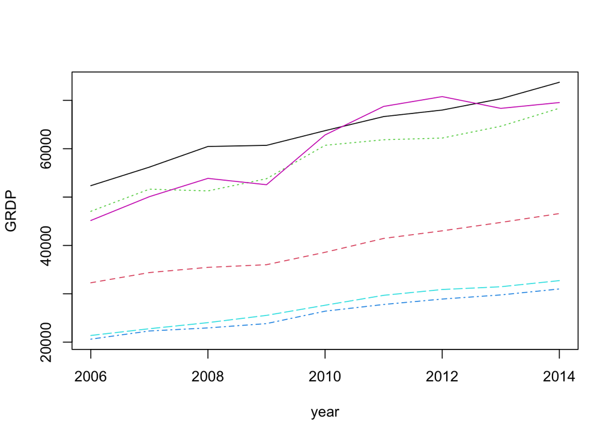

```r
matplot(seq(2006, 2014), t(df[3:8, -1]), type = "l", xlab = "year", ylab = "GRDP")
```